# Mushroom Classification Analysis

## Introduction

In this notebook, we will perform a comprehensive analysis of the mushroom dataset to classify mushrooms as **edible** or **poisonous**. The goal is to build a robust machine learning model that can accurately distinguish between these two classes based on various mushroom characteristics.

### Dataset Overview

Let's dive into the analysis!

```python
import sys
import os

# Add the root directory to the Python path
root_dir = os.path.abspath(os.path.join(os.getcwd(), ".."))
if root_dir not in sys.path:
    sys.path.append(root_dir)
sys.path.append("../Utils")
```

```python
import pandas as pd
import numpy as np

import seaborn as sns
import matplotlib.pyplot as plt
import graphviz

from sklearn.model_selection import train_test_split
from sklearn.preprocessing import StandardScaler, OneHotEncoder
from sklearn.naive_bayes import GaussianNB
from sklearn.ensemble import RandomForestClassifier
from sklearn import tree
from sklearn.linear_model import LogisticRegression
from sklearn.svm import SVC
from sklearn.neighbors import KNeighborsClassifier
import xgboost as xgb
from sklearn.preprocessing import LabelEncoder
from sklearn.preprocessing import StandardScaler
from sklearn.metrics import roc_curve, auc
from sklearn.manifold import TSNE

from tools import (process_models, plot_roc_curves,
                   map_series_with_dict, rename_columns,
                   analyze_models,
                   visualize_shared_feature_importances,
                   aggregate_onehot_feature_importances,
                   plot_aggregated_feature_importances_heatmap,
                   plot_tsne, perform_rfe, calculate_mutual_info,
                   get_styled_results,
                   calculate_chi2_for_features,
                   perform_feature_selection_analysis,
                   select_top_n_indices, analyze_features,
                   styled_df_to_latex)
```

## Data Preprocessing

Before we can train our models, we need to preprocess the data. This involves handling missing values, encoding categorical features, and splitting the data into training and testing sets.

### Step 1: Load and Clean the Data

- **Load the dataset**: We'll start by loading the dataset from the CSV file.
- **Handle missing values**: The `stalk_root` column has 2,480 missing values. We'll drop this column to simplify our analysis.
- **Encode categorical features**: Since all features are categorical, we'll use **one-hot encoding** to convert them into numerical format.
- **Split the data**: We'll split the data into training (70%) and testing (30%) sets.

#### Why One-Hot Encoding?

Categorical features (e.g., `cap_shape`, `cap_color`) cannot be directly used in machine learning models because they are not numerical. **One-hot encoding** converts these categorical features into binary vectors, where each category is represented as a separate column with a value of 0 or 1. This allows models to process categorical data effectively.

#### Read the data from the CSV file

```python
# reading the raw CSV data file
csv_df = pd.read_csv("../Data/mushroom/agaricus-lepiota.data")
csv_df.head()
```

|  | p | x | s | n | t | p.1 | f | c | n.1 | k | ... | s.2 | w | w.1 | p.2 | w.2 | o | p.3 | k.1 | s.3 | u |
| --- | --- | --- | --- | --- | --- | --- | --- | --- | --- | --- | --- | --- | --- | --- | --- | --- | --- | --- | --- | --- | --- |
| 0 | e | x | s | y | t | a | f | c | b | k | ... | s | w | w | p | w | o | p | n | n | g |
| 1 | e | b | s | w | t | l | f | c | b | n | ... | s | w | w | p | w | o | p | n | n | m |
| 2 | p | x | y | w | t | p | f | c | n | n | ... | s | w | w | p | w | o | p | k | s | u |
| 3 | e | x | s | g | f | n | f | w | b | k | ... | s | w | w | p | w | o | e | n | a | g |
| 4 | e | x | y | y | t | a | f | c | b | n | ... | s | w | w | p | w | o | p | k | n | g |

5 rows × 23 columns

#### Let's replace the 'encoded' feature names with the full names.

```python
# Rename columns
original_csv_df = csv_df.copy()
csv_df = rename_columns(csv_df)
```

```python
csv_df.shape
```

```
(8123, 23)
```

#### Let's confirm that all missing values are in column 11

```python
# finding columns in the df which have any null/na values
csv_df.replace('?', np.nan, inplace=True)
np.where(pd.isna(csv_df))
```

```
(array([3983, 4022, 4075, ..., 8120, 8121, 8122]),
 array([11, 11, 11, ..., 11, 11, 11]))
```

```python
# Checking the missing values
series = csv_df.isnull().sum()
non_zero_lines = series[series != 0]

print(non_zero_lines)
```

```
stalk_root    2480
dtype: int64
```

#### Make sure there is no duplicate

```python
csv_df = csv_df.drop_duplicates()
csv_df.shape
```

```
(8123, 23)
```

```python
# getting unique values from each column, so we know which values to convert to numerical
for col in csv_df.columns:
    print(col, csv_df[col].unique())
```

```
class ['e' 'p']
cap_shape ['x' 'b' 's' 'f' 'k' 'c']
cap_surface ['s' 'y' 'f' 'g']
cap_color ['y' 'w' 'g' 'n' 'e' 'p' 'b' 'u' 'c' 'r']
bruises ['t' 'f']
odor ['a' 'l' 'p' 'n' 'f' 'c' 'y' 's' 'm']
gill_attachment ['f' 'a']
gill_spacing ['c' 'w']
gill_size ['b' 'n']
gill_color ['k' 'n' 'g' 'p' 'w' 'h' 'u' 'e' 'b' 'r' 'y' 'o']
stalk_shape ['e' 't']
stalk_root ['c' 'e' 'b' 'r' nan]
stalk_surface_above_ring ['s' 'f' 'k' 'y']
stalk_surface_below_ring ['s' 'f' 'y' 'k']
stalk_color_above_ring ['w' 'g' 'p' 'n' 'b' 'e' 'o' 'c' 'y']
stalk_color_below_ring ['w' 'p' 'g' 'b' 'n' 'e' 'y' 'o' 'c']
veil_type ['p']
veil_color ['w' 'n' 'o' 'y']
ring_number ['o' 't' 'n']
ring_type ['p' 'e' 'l' 'f' 'n']
spore_print_color ['n' 'k' 'u' 'h' 'w' 'r' 'o' 'y' 'b']
population ['n' 's' 'a' 'v' 'y' 'c']
habitat ['g' 'm' 'u' 'd' 'p' 'w' 'l']
```

#### Let's remove the feature 'stalk-root' from the data.

```python
csv_df = csv_df.drop('stalk_root', axis=1)
csv_df
```

|  | class | cap_shape | cap_surface | cap_color | bruises | odor | gill_attachment | gill_spacing | gill_size | gill_color | ... | stalk_surface_below_ring | stalk_color_above_ring | stalk_color_below_ring | veil_type | veil_color | ring_number | ring_type | spore_print_color | population | habitat |
| --- | --- | --- | --- | --- | --- | --- | --- | --- | --- | --- | --- | --- | --- | --- | --- | --- | --- | --- | --- | --- | --- |
| 0 | e | x | s | y | t | a | f | c | b | k | ... | s | w | w | p | w | o | p | n | n | g |
| 1 | e | b | s | w | t | l | f | c | b | n | ... | s | w | w | p | w | o | p | n | n | m |
| 2 | p | x | y | w | t | p | f | c | n | n | ... | s | w | w | p | w | o | p | k | s | u |
| 3 | e | x | s | g | f | n | f | w | b | k | ... | s | w | w | p | w | o | e | n | a | g |
| 4 | e | x | y | y | t | a | f | c | b | n | ... | s | w | w | p | w | o | p | k | n | g |
| ... | ... | ... | ... | ... | ... | ... | ... | ... | ... | ... | ... | ... | ... | ... | ... | ... | ... | ... | ... | ... | ... |
| 8118 | e | k | s | n | f | n | a | c | b | y | ... | s | o | o | p | o | o | p | b | c | l |
| 8119 | e | x | s | n | f | n | a | c | b | y | ... | s | o | o | p | n | o | p | b | v | l |
| 8120 | e | f | s | n | f | n | a | c | b | n | ... | s | o | o | p | o | o | p | b | c | l |
| 8121 | p | k | y | n | f | y | f | c | n | b | ... | k | w | w | p | w | o | e | w | v | l |
| 8122 | e | x | s | n | f | n | a | c | b | y | ... | s | o | o | p | o | o | p | o | c | l |

8123 rows × 22 columns

#### Drop the column 'veil_type' since it as only one value 'p'.

```python
csv_df = csv_df.drop('veil_type', axis=1)
```

#### Let's verify that we have a well balanced dataset

```python
# Calculate the value counts
counts = csv_df['class'].value_counts()

# Calculate the ratio
total_count = counts.sum()  # Total number of rows
ratios = counts / total_count

# Combine counts and ratios into a DataFrame
result = pd.DataFrame({'Count': counts, 'Ratio': ratios})

# Display the result
print(result)
```

```
       Count     Ratio
class
e       4208  0.518035
p       3915  0.481965
```

```python
X = csv_df.drop(['class'],axis=1)
Y = csv_df['class']
```

#### One-Hot Encoding

Since all features are categorical, we'll use **one-hot encoding** to convert them into numerical format. This will allow us to use them in machine learning models.

Since I want to use **precision** to ensure that mushrooms predicted as edible are indeed edible, I must encode the target such that 'e' (edible) is the positive class (i.e., {'e': 1, 'p': 0}). This is because the default value of `pos_label` in scikit-learn's precision_score and recall_score is **1**, and these metrics are calculated with respect to the positive class.

**Why This Matters**

```
Precision measures how many of the predicted positives are actually positive.

If 'e' (edible) is the positive class (1), precision will measure how many mushrooms predicted as edible are indeed edible.

If 'p' (poisonous) is the positive class (1), precision will measure how many mushrooms predicted as poisonous are indeed poisonous.
```

If you want to change the positive class, you can explicitly set pos_label to the desired value (e.g., pos_label=0 to treat 'e' as positive when encoded as 0).

```python
# Let's transform 'e' (edible) and 'p' (poisonous) into 1 and 0 respectively.
target_encoding = {'e':1, 'p':0}
Y_onehot = Y.map(target_encoding)
```

```python
# creating train/test split using 70% data for training and 30% for testing
X_train, X_test, y_train, y_test = train_test_split(X, Y_onehot, test_size = 0.3, random_state = 42)
```

```python
# Initialize the OneHotEncoder
preprocessor = OneHotEncoder(sparse_output=False)

# Apply preprocessing and convert back to DataFrame
X_train = pd.DataFrame(preprocessor.fit_transform(X_train), columns=preprocessor.get_feature_names_out())
X_test = pd.DataFrame(preprocessor.transform(X_test), columns=preprocessor.get_feature_names_out())
```

## Model Training and Evaluation

### Step 2: Train Multiple Models

We will train and evaluate the following models:

- **Naive Bayes**: A probabilistic classifier based on Bayes' theorem. It assumes that features are independent of each other, making it fast and simple.
- **Random Forest**: An ensemble of decision trees that reduces overfitting by averaging multiple trees. It is robust and handles non-linear relationships well.
- **Decision Tree**: A tree-based model that splits the data based on feature values. It is interpretable but prone to overfitting.
- **Logistic Regression**: A linear model for binary classification. It models the probability of the target class using a logistic function.
- **SVC (Linear/RBF)**: Support Vector Machine with different kernels. Linear SVC works well for linearly separable data, while RBF SVC can handle non-linear data.
- **KNN**: Classification based on nearest neighbors. It predicts the class of a sample based on the majority class of its k-nearest neighbors.
- **XGBoost**: A gradient boosting algorithm that builds trees sequentially, correcting errors from previous trees. It is highly accurate and scalable.

#### Why Multiple Models?

Different models have different strengths and weaknesses. By comparing multiple models, we can identify the best-performing one for this dataset.

```python
# List of models
models = [
    ("Naive Bayes", GaussianNB, {}),
    ("Random Forest", RandomForestClassifier, {}),
    ("Decision Tree", tree.DecisionTreeClassifier, {}),
    ("Logistic Regression", LogisticRegression, {}),
    ("SVC (Linear)", SVC, {"kernel": 'linear'}),
    ("KSVC (RBF)", SVC, {"kernel": 'rbf'}),
    ("KNN", KNeighborsClassifier, {}),
    ("XGBoost", xgb.XGBClassifier, {})
]
```

```python
# Process all models
performance_metrics, feature_importances, _ = process_models(
    models, X_train, X_test, y_train, y_test
)
```

```
Processing Naive Bayes...
Processing Random Forest...
Processing Decision Tree...
Processing Logistic Regression...
Processing SVC (Linear)...
Processing KSVC (RBF)...
Processing KNN...
Processing XGBoost...
```

#### Checking each model performances

```python
# Print performance metrics in a DataFrame
_ = analyze_models(performance_metrics, feature_importances, target_encoding)
```

```
Performance Metrics DataFrame (Sorted by precision):
```

| Model | accuracy | recall | precision | f1 | roc_auc |
| --- | --- | --- | --- | --- | --- |
| Naive Bayes | 0.989331 | 0.979592 | 1.000000 | 0.989691 | 0.989796 |
| Random Forest | 1.000000 | 1.000000 | 1.000000 | 1.000000 | 1.000000 |
| Decision Tree | 1.000000 | 1.000000 | 1.000000 | 1.000000 | 1.000000 |
| Logistic Regression | 1.000000 | 1.000000 | 1.000000 | 1.000000 | 1.000000 |
| SVC (Linear) | 1.000000 | 1.000000 | 1.000000 | 1.000000 | 1.000000 |
| KSVC (RBF) | 1.000000 | 1.000000 | 1.000000 | 1.000000 | 1.000000 |
| KNN | 1.000000 | 1.000000 | 1.000000 | 1.000000 | 1.000000 |
| XGBoost | 1.000000 | 1.000000 | 1.000000 | 1.000000 | 1.000000 |

```
Top 5 Feature Importances for Random Forest:
odor_n                        0.166875
odor_f                        0.069150
gill_size_b                   0.055740
gill_size_n                   0.052238
stalk_surface_below_ring_k    0.047714
dtype: float64
```

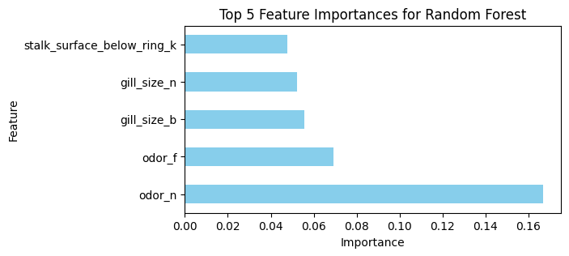

```
Top 5 Feature Importances for Decision Tree:
odor_n                 0.623044
bruises_f              0.163930
odor_p                 0.092107
odor_f                 0.065186
spore_print_color_r    0.030096
dtype: float64
```

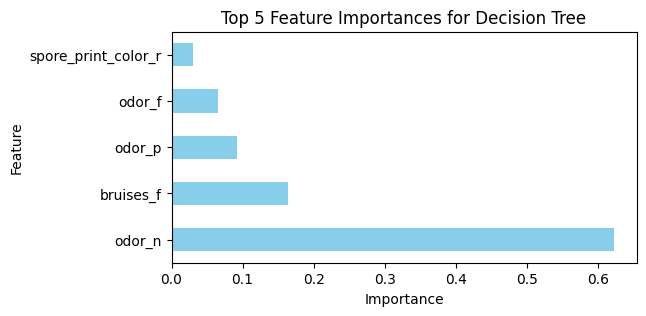

```
Top 5 Feature Importances for XGBoost:
odor_n                 0.464841
odor_p                 0.183402
bruises_f              0.113484
odor_f                 0.101135
spore_print_color_r    0.062928
dtype: float32
```

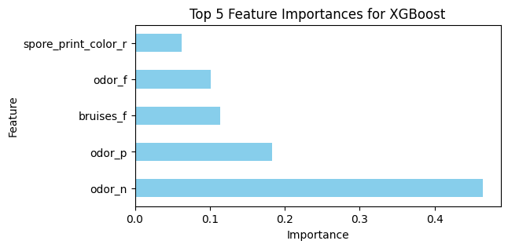

```python
# Plot feature importances
_ = analyze_models(performance_metrics, feature_importances,
                   target_encoding,
                   print_metrics_df=False,
                   plot_importances=True)
```

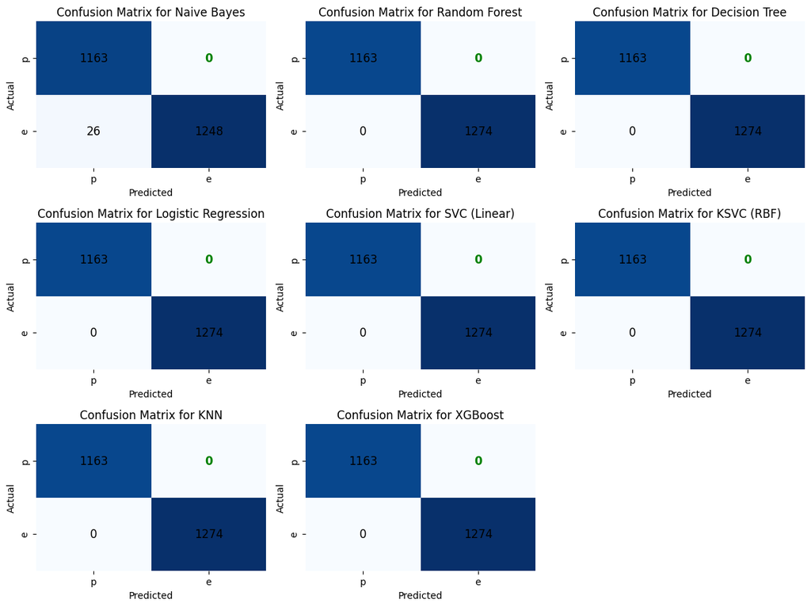

```python
# Plot confusion matrices
_ = analyze_models(performance_metrics, feature_importances,
                   target_encoding,
                   print_metrics_df=False,
                   plot_confusion_matrices=True)
```

## Feature Importance Analysis

### Step 3: Visualize Feature Importances

Feature importance measures how much each feature contributes to the model's predictions. We will visualize the feature importances from the trained models to understand which features are most important for classification.

#### Why Feature Importance?

Understanding feature importance helps us:

- Identify the most relevant features for classification.
- Reduce the number of features (dimensionality reduction) to improve model efficiency.
- Gain insights into the dataset and the problem domain.

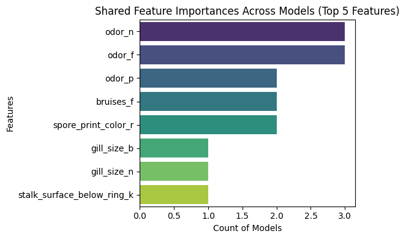

```python
visualize_shared_feature_importances(feature_importances)
```

```python
# Plot ROC curves
#plot_roc_curves(models, X_train, X_test, y_train, y_test)
```

```python
aggregated_df, styled_df = aggregate_onehot_feature_importances(feature_importances, X.columns, n=4)
styled_df
```

|  | Random Forest | Decision Tree | XGBoost |
| --- | --- | --- | --- |
| odor | 0.291541 | 0.780337 | 0.769224 |
| bruises | 0.067577 | 0.163930 | 0.113484 |
| spore_print_color | 0.087712 | 0.030096 | 0.064779 |
| stalk_surface_below_ring | 0.075613 | 0.016979 | 0.038023 |
| gill_size | 0.107978 | 0.005852 | 0.004119 |
| stalk_surface_above_ring | 0.054174 | 0.000000 | 0.001915 |
| population | 0.052047 | 0.000000 | 0.000918 |
| ring_type | 0.050498 | 0.000000 | 0.000317 |
| gill_color | 0.042185 | 0.000000 | 0.000080 |
| habitat | 0.038553 | 0.000000 | 0.000222 |
| gill_spacing | 0.032786 | 0.000000 | 0.000105 |
| stalk_shape | 0.025630 | 0.000000 | 0.001739 |
| cap_color | 0.016412 | 0.000000 | 0.000902 |
| stalk_color_below_ring | 0.014823 | 0.000000 | 0.001526 |
| cap_surface | 0.010843 | 0.002103 | 0.000641 |
| ring_number | 0.010924 | 0.000000 | 0.000688 |
| stalk_color_above_ring | 0.010802 | 0.000000 | 0.000733 |
| cap_shape | 0.006274 | 0.000702 | 0.000584 |
| gill_attachment | 0.002246 | 0.000000 | 0.000000 |
| veil_color | 0.001381 | 0.000000 | 0.000000 |

```python
#latex_code = styled_df_to_latex(aggregated_df, n=5, decimals=4)
#print(latex_code)
```

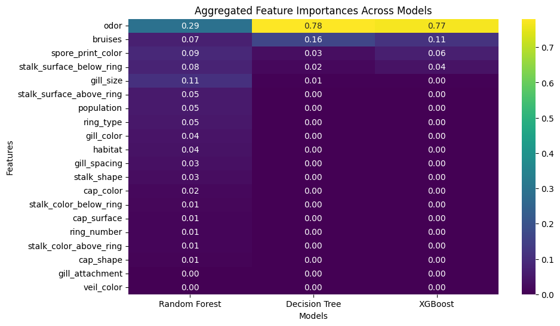

```python
plot_aggregated_feature_importances_heatmap(aggregated_df)
```

#### Using t-SNE for Visualization

t-SNE (t-Distributed Stochastic Neighbor Embedding) is a technique for dimensionality reduction that is particularly well-suited for visualizing high-dimensional datasets. We'll use it to visualize the dataset in 2D space.

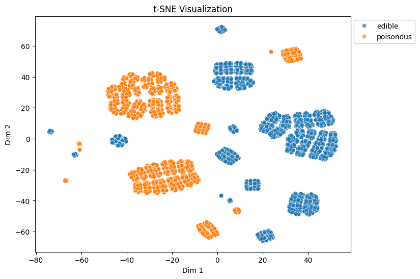

```python
plot_tsne(pd.get_dummies(X), csv_df, title="t-SNE Visualization")
```

[figure not shown]

```python
plot_tsne(pd.get_dummies(X), csv_df, feature_to_add1='odor',
          title="t-SNE Visualization with Odor")
```

**As we can see, the 'odor' attribute is separating the edible and poisonous mushrooms almost perfectly.**

**This suggests that `odor` is a highly discriminative feature for classification.**

```python
%%script false --no-raise-error  # Cell deactivated
plot_tsne(pd.get_dummies(X), csv_df, feature_to_add1='odor',
          feature_to_add2='gill_size',
          title="t-SNE Visualization with Odor and Bruises")
```

```python
%%script false --no-raise-error # Cell deactivated
plot_tsne(pd.get_dummies(X), csv_df, feature_to_add1='odor',
          feature_to_add2='stalk_surface_above_ring',
          title="t-SNE Visualization with Odor and Ring Type")
```

## Feature Selection Techniques

### Step 4: Identify Important Features

We will use the following techniques to select the most important features:

- **Recursive Feature Elimination (RFE)**: Recursively removes the least important features and builds the model until the specified number of features is reached.
- **Mutual Information**: Measures the dependency between features and the target. Higher mutual information indicates a stronger relationship.
- **Chi-Square Test**: Evaluates the relationship between categorical features and the target. It is particularly useful for categorical data.

#### Why Feature Selection?

Feature selection helps us:

- Reduce overfitting by removing irrelevant features.
- Improve model performance by focusing on the most important features.
- Reduce training time and computational cost.

```python
# Define the models for RFE
rfe_models = [
    ('RF', RandomForestClassifier()),
    ("Decision Tree", tree.DecisionTreeClassifier()),
    ('XGB', xgb.XGBClassifier())
]
```

```python
# Perform feature selection analysis for all features, sorted by 'Mutual Information' scores
combined_results = perform_feature_selection_analysis(
    X_train, y_train, rfe_models, X.columns,
    n_features_to_select=10, sort_by='Mutual Information'
)
```

```python
# Display the styled DataFrame
styled_results = get_styled_results(combined_results)
styled_results
```

|  | RF RFE | Decision Tree RFE | XGB RFE | Mutual Information | Chi-Square |
| --- | --- | --- | --- | --- | --- |
| odor | 2 | 2 | 5 | 0.845246 | 5.744254 |
| spore_print_color | 1 | 2 | 1 | 0.412831 | 4.255771 |
| gill_color | 1 | 0 | 0 | 0.362672 | 12.709006 |
| stalk_surface_above_ring | 1 | 0 | 0 | 0.343159 | 4.851337 |
| gill_size | 2 | 1 | 1 | 0.320071 | 0.025616 |
| ring_type | 1 | 0 | 0 | 0.316684 | 7.105163 |
| stalk_surface_below_ring | 1 | 1 | 1 | 0.291457 | 7.307589 |
| bruises | 0 | 1 | 1 | 0.280661 | 3.222144 |
| stalk_color_below_ring | 0 | 0 | 0 | 0.225129 | 7.482289 |
| stalk_color_above_ring | 0 | 0 | 0 | 0.198297 | 3.957266 |
| population | 0 | 0 | 1 | 0.195182 | 4.064947 |
| gill_spacing | 0 | 0 | 0 | 0.124402 | 1.352531 |
| habitat | 0 | 0 | 0 | 0.118462 | 4.347091 |
| cap_color | 0 | 0 | 0 | 0.049094 | 12.855670 |
| ring_number | 0 | 1 | 0 | 0.048279 | 1.437932 |
| cap_shape | 0 | 1 | 0 | 0.044443 | 1.941632 |
| veil_color | 0 | 0 | 0 | 0.033851 | 0.481163 |
| stalk_shape | 1 | 0 | 0 | 0.025711 | 6.209736 |
| gill_attachment | 0 | 0 | 0 | 0.025551 | 0.523779 |
| cap_surface | 0 | 1 | 0 | 0.020375 | 0.684580 |

### Let's select a reduced set of features

```python
# Select top indices from the 'Mutual Information' column
num_features = 4
try:
    top_n_indices = select_top_n_indices(combined_results, 'Mutual Information', num_features)
    print(f"Top {num_features} indices from Mutual Information column: {top_n_indices}")
except ValueError as e:
    print(e)
```

```
Top 4 indices from Mutual Information column: Index(['odor', 'spore_print_color', 'gill_color', 'stalk_surface_above_ring'], dtype='object')
```

```python
_, performance_metrics, feature_importance, _, _, _, _ = analyze_features(csv_df, top_n_indices, models)
```

```
Processing Naive Bayes...
Processing Random Forest...
Processing Decision Tree...
Processing Logistic Regression...
Processing SVC (Linear)...
Processing KSVC (RBF)...
Processing KNN...
Processing XGBoost...
```

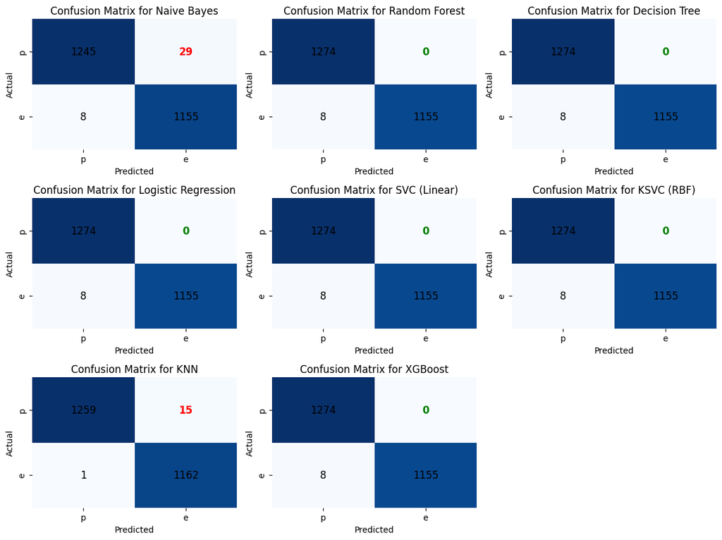

| Model | accuracy | recall | precision | f1 | roc_auc |
| --- | --- | --- | --- | --- | --- |
| Random Forest | 0.996717 | 0.993121 | 1.000000 | 0.996549 | 0.996561 |
| Decision Tree | 0.996717 | 0.993121 | 1.000000 | 0.996549 | 0.996561 |
| Logistic Regression | 0.996717 | 0.993121 | 1.000000 | 0.996549 | 0.996561 |
| SVC (Linear) | 0.996717 | 0.993121 | 1.000000 | 0.996549 | 0.996561 |
| KSVC (RBF) | 0.996717 | 0.993121 | 1.000000 | 0.996549 | 0.996561 |
| XGBoost | 0.996717 | 0.993121 | 1.000000 | 0.996549 | 0.996561 |
| KNN | 0.993435 | 0.999140 | 0.987256 | 0.993162 | 0.993683 |
| Naive Bayes | 0.984817 | 0.993121 | 0.975507 | 0.984235 | 0.985179 |

```python
# Print performance metrics in a DataFrame
performance_df = analyze_models(performance_metrics,
                                feature_importances,
                                target_encoding,
                                print_metrics_df=False,
                                plot_confusion_matrices=True)
performance_df
```

With only **4 features**, we still have a precision of **1** for almost all models. We lost a bit in accuracy, but this is not very important.

Let's try with **5 features**.

```python
num_features = 5
try:
    top_n_indices = select_top_n_indices(combined_results, 'Mutual Information', num_features)
    print(f"Top {num_features} indices from Mutual Information column: {top_n_indices}")
except ValueError as e:
    print(e)
```

```
Top 5 indices from Mutual Information column: Index(['odor', 'spore_print_color', 'gill_color', 'stalk_surface_above_ring',
       'gill_size'],
      dtype='object')
```

```
Processing Naive Bayes...
Processing Random Forest...
Processing Decision Tree...
Processing Logistic Regression...
Processing SVC (Linear)...
Processing KSVC (RBF)...
Processing KNN...
Processing XGBoost...
```

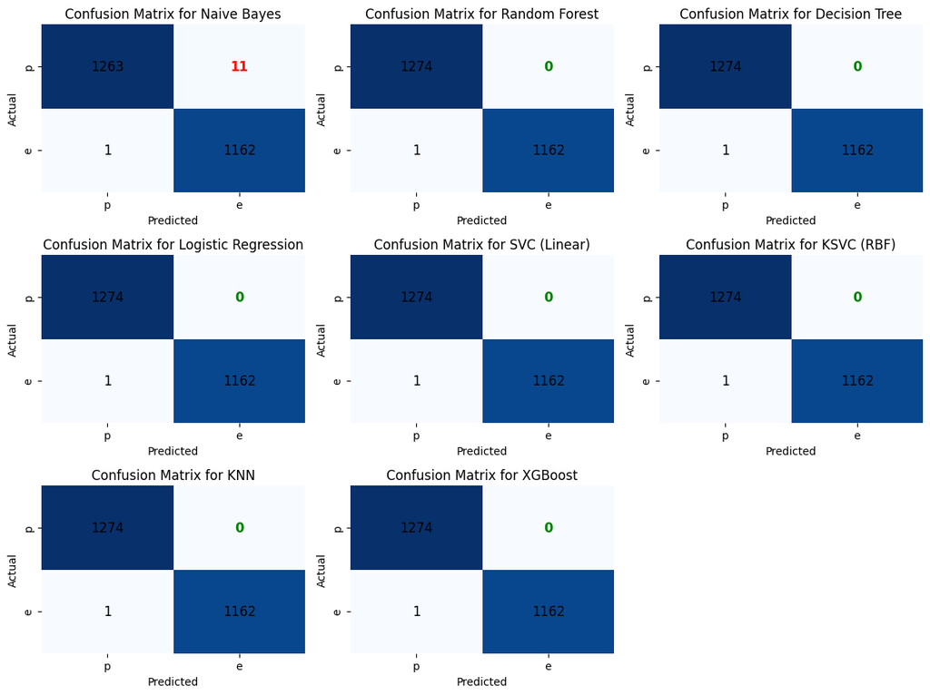

| Model | accuracy | recall | precision | f1 | roc_auc |
| --- | --- | --- | --- | --- | --- |
| Random Forest | 0.999590 | 0.999140 | 1.000000 | 0.999570 | 0.999570 |
| Decision Tree | 0.999590 | 0.999140 | 1.000000 | 0.999570 | 0.999570 |
| Logistic Regression | 0.999590 | 0.999140 | 1.000000 | 0.999570 | 0.999570 |
| SVC (Linear) | 0.999590 | 0.999140 | 1.000000 | 0.999570 | 0.999570 |
| KSVC (RBF) | 0.999590 | 0.999140 | 1.000000 | 0.999570 | 0.999570 |
| KNN | 0.999590 | 0.999140 | 1.000000 | 0.999570 | 0.999570 |
| XGBoost | 0.999590 | 0.999140 | 1.000000 | 0.999570 | 0.999570 |
| Naive Bayes | 0.995076 | 0.999140 | 0.990622 | 0.994863 | 0.995253 |

```python
_, performance_metrics, feature_importance, _, _, _, _ = analyze_features(csv_df, top_n_indices, models)

performance_df = analyze_models(performance_metrics,
                                feature_importances,
                                target_encoding,
                                print_metrics_df=False,
                                plot_confusion_matrices=True)
performance_df
```

#### **Feature Selection: Dropping Some Features**

To refine our dataset, we’ll remove certain features that are impractical for real-world use.

1. **Dropping 'odor'**:
   - **Reason 1**: To increase the challenge for classifiers, as they currently rely heavily on this feature.
   - **Reason 2**: To focus exclusively on **visual characteristics** of the mushrooms, making the model more aligned with practical scenarios where only visual inspection is possible.
2. **Dropping 'population' and 'habitat'**:
   - **Reason**: These features are not directly observable when handling a mushroom. Since our goal is to create a model that works with **immediate, observable attributes**, these features are excluded.

#### Let's first remove 'odor' only

```python
# List of features to remove
features_to_remove = ['odor']

filtered_features = [col for col in csv_df.columns if col not in features_to_remove]

(_, performance_metrics, feature_importances,
 X_filtered_train, y_filtered_train, X_filtered_test, y_filtered_test) = analyze_features(csv_df, filtered_features, models)
```

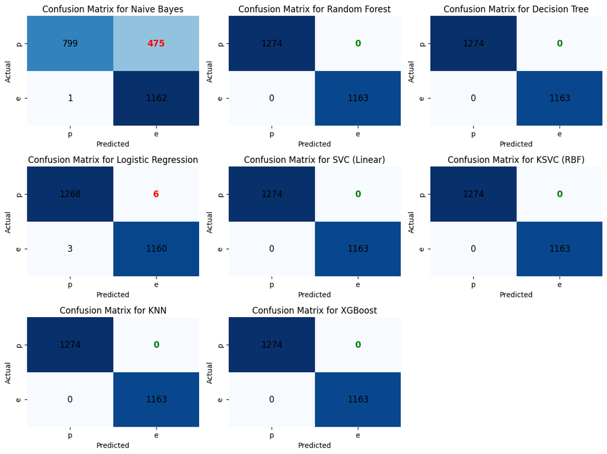

| Model | accuracy | recall | precision | f1 | roc_auc |
| --- | --- | --- | --- | --- | --- |
| Random Forest | 1.000000 | 1.000000 | 1.000000 | 1.000000 | 1.000000 |
| Decision Tree | 1.000000 | 1.000000 | 1.000000 | 1.000000 | 1.000000 |
| SVC (Linear) | 1.000000 | 1.000000 | 1.000000 | 1.000000 | 1.000000 |
| KSVC (RBF) | 1.000000 | 1.000000 | 1.000000 | 1.000000 | 1.000000 |
| KNN | 1.000000 | 1.000000 | 1.000000 | 1.000000 | 1.000000 |
| XGBoost | 1.000000 | 1.000000 | 1.000000 | 1.000000 | 1.000000 |
| Logistic Regression | 0.996307 | 0.997420 | 0.994854 | 0.996136 | 0.996355 |
| Naive Bayes | 0.804678 | 0.999140 | 0.709835 | 0.830000 | 0.813149 |

```python
# Print performance metrics in a DataFrame
performance_df = analyze_models(performance_metrics,
                                feature_importances,
                                target_encoding,
                                print_metrics_df=False,
                                plot_confusion_matrices=True)
performance_df
```

So, we are still able to get some perfect classifiers.

Let's see if we can reduce the number of features.

```python
# Perform feature selection analysis for all features
num_features = 12
combined_results = perform_feature_selection_analysis(
    X_filtered_train, y_filtered_train, rfe_models, X.columns,
    n_features_to_select=num_features, sort_by='Mutual Information'
)
# Display the styled DataFrame
styled_results = get_styled_results(combined_results, top_n=num_features)
styled_results
```

|  | RF RFE | Decision Tree RFE | XGB RFE | Mutual Information | Chi-Square |
| --- | --- | --- | --- | --- | --- |
| spore_print_color | 1 | 4 | 3 | 0.406638 | 4.255771 |
| stalk_surface_above_ring | 1 | 1 | 1 | 0.349381 | 4.851337 |
| gill_color | 1 | 0 | 1 | 0.334115 | 12.709006 |
| ring_type | 2 | 0 | 0 | 0.317270 | 7.105163 |
| gill_size | 2 | 1 | 1 | 0.307406 | 0.025616 |
| stalk_surface_below_ring | 1 | 1 | 2 | 0.306942 | 7.307589 |
| bruises | 1 | 0 | 0 | 0.267507 | 3.222144 |
| population | 0 | 0 | 1 | 0.214887 | 4.064947 |
| stalk_color_above_ring | 0 | 0 | 0 | 0.209379 | 3.957266 |
| stalk_color_below_ring | 0 | 1 | 0 | 0.158198 | 7.482289 |
| gill_spacing | 1 | 1 | 1 | 0.124658 | 1.352531 |
| habitat | 1 | 1 | 1 | 0.106499 | 4.347091 |
| cap_shape | 0 | 0 | 0 | 0.056624 | 1.941632 |
| ring_number | 0 | 0 | 0 | 0.046370 | 1.437932 |
| cap_color | 0 | 0 | 0 | 0.040840 | 12.855670 |
| cap_surface | 0 | 1 | 1 | 0.032792 | 0.684580 |
| veil_color | 0 | 0 | 0 | 0.018965 | 0.481163 |
| gill_attachment | 0 | 0 | 0 | 0.018489 | 0.523779 |
| stalk_shape | 1 | 1 | 0 | 0.006650 | 6.209736 |
| odor | 0 | 0 | 0 | 0.000000 | 0.000000 |

```python
# Select top n indices from the 'Mutual Information' column
try:
    top_n_indices = select_top_n_indices(combined_results, 'Mutual Information', num_features)
    print(f"Top {num_features} indices from Mutual Information column: {top_n_indices}")
except ValueError as e:
    print(e)
```

```
Top 12 indices from Mutual Information column: Index(['spore_print_color', 'stalk_surface_above_ring', 'gill_color',
       'ring_type', 'gill_size', 'stalk_surface_below_ring', 'bruises',
       'population', 'stalk_color_above_ring', 'stalk_color_below_ring',
       'gill_spacing', 'habitat'],
      dtype='object')
```

```python
fitted_models, performance_metrics, feature_importance, _, _, _, _ = analyze_features(csv_df, top_n_indices, models)
```

```
Processing Naive Bayes...
Processing Random Forest...
Processing Decision Tree...
Processing Logistic Regression...
Processing SVC (Linear)...
Processing KSVC (RBF)...
Processing KNN...
Processing XGBoost...
```

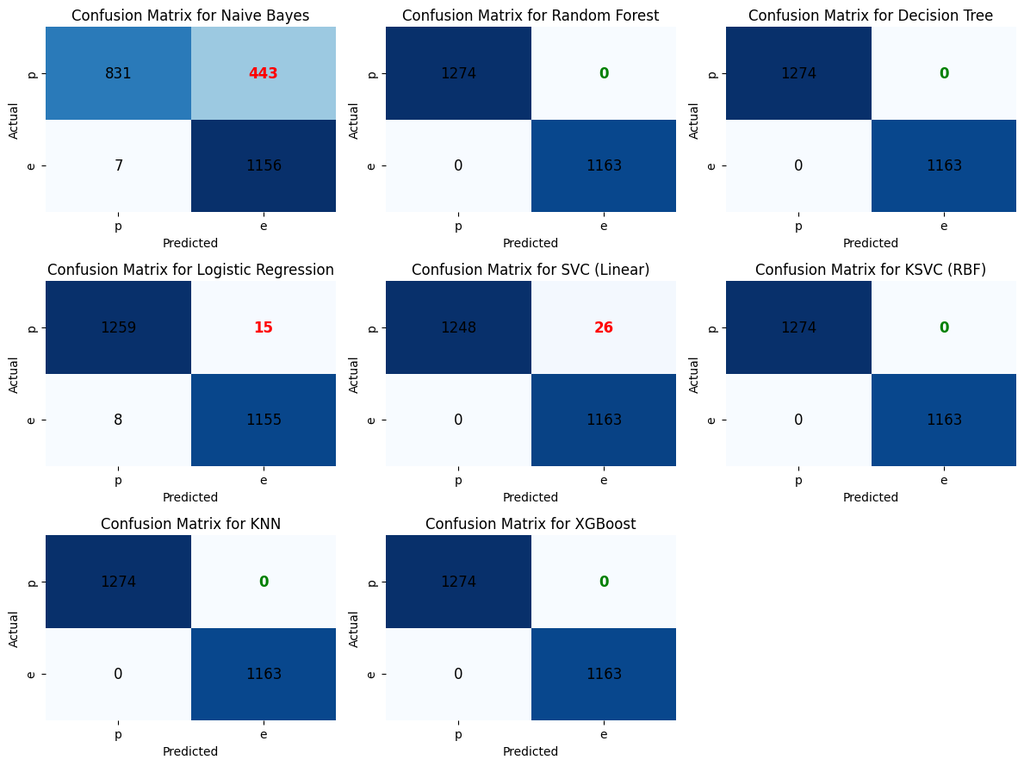

| Model | accuracy | recall | precision | f1 | roc_auc |
| --- | --- | --- | --- | --- | --- |
| Random Forest | 1.000000 | 1.000000 | 1.000000 | 1.000000 | 1.000000 |
| Decision Tree | 1.000000 | 1.000000 | 1.000000 | 1.000000 | 1.000000 |
| KSVC (RBF) | 1.000000 | 1.000000 | 1.000000 | 1.000000 | 1.000000 |
| KNN | 1.000000 | 1.000000 | 1.000000 | 1.000000 | 1.000000 |
| XGBoost | 1.000000 | 1.000000 | 1.000000 | 1.000000 | 1.000000 |
| Logistic Regression | 0.990562 | 0.993121 | 0.987179 | 0.990141 | 0.990674 |
| SVC (Linear) | 0.989331 | 1.000000 | 0.978133 | 0.988946 | 0.989796 |
| Naive Bayes | 0.815347 | 0.993981 | 0.722952 | 0.837075 | 0.823129 |

```python
# Print performance metrics in a DataFrame
analyze_models(performance_metrics,
               feature_importance,
               target_encoding,
               print_metrics_df=False,
               plot_confusion_matrices=True)
```

So, with just **12 features**, we still have the **Random Forest**, **Decision Tree**, **KSVC**, **KNN**, and **XGBoost** models that have a perfect score.

#### Let's also drop 'population' and 'habitat'

```python
# List of features to remove
features_to_remove = ['odor', 'population', 'habitat']
```

```python
filtered_features = [col for col in csv_df.columns if col not in features_to_remove]

(_, performance_metrics, feature_importances,
 X_filtered_train, y_filtered_train, X_filtered_test, y_filtered_test) = analyze_features(csv_df, filtered_features, models)
```

```python
# Print performance metrics in a DataFrame
performance_df = analyze_models(performance_metrics,
                                feature_importances,
                                target_encoding,
                                print_metrics_df=False)
performance_df
```

| Model | accuracy | recall | precision | f1 | roc_auc |
| --- | --- | --- | --- | --- | --- |
| KNN | 0.998359 | 0.999140 | 0.997425 | 0.998282 | 0.998393 |
| Decision Tree | 0.997948 | 0.998280 | 0.997423 | 0.997851 | 0.997963 |
| KSVC (RBF) | 0.998359 | 1.000000 | 0.996572 | 0.998283 | 0.998430 |
| Random Forest | 0.997948 | 0.999140 | 0.996569 | 0.997853 | 0.998000 |
| XGBoost | 0.997948 | 0.999140 | 0.996569 | 0.997853 | 0.998000 |
| SVC (Linear) | 0.997948 | 1.000000 | 0.995719 | 0.997855 | 0.998038 |
| Logistic Regression | 0.993845 | 0.996561 | 0.990598 | 0.993571 | 0.993963 |
| Naive Bayes | 0.855970 | 0.991402 | 0.771754 | 0.867896 | 0.861870 |

##### So now, none of our models has a precision of 1.

```python
# Perform feature selection analysis for all features, sorted by 'Mutual Information' scores
num_features = 14
combined_results = perform_feature_selection_analysis(
    X_filtered_train, y_filtered_train, rfe_models, X.columns,
    n_features_to_select=num_features, sort_by='Mutual Information'
)
# Display the styled DataFrame
styled_results = get_styled_results(combined_results)
styled_results
```

|  | RF RFE | Decision Tree RFE | XGB RFE | Mutual Information | Chi-Square |
| --- | --- | --- | --- | --- | --- |
| spore_print_color | 1 | 2 | 3 | 0.427655 | 4.255771 |
| stalk_surface_above_ring | 2 | 1 | 1 | 0.338968 | 4.851337 |
| ring_type | 1 | 0 | 0 | 0.328828 | 7.105163 |
| gill_color | 1 | 2 | 1 | 0.317899 | 12.709006 |
| stalk_surface_below_ring | 1 | 1 | 2 | 0.312422 | 7.307589 |
| gill_size | 2 | 1 | 1 | 0.307187 | 0.025616 |
| bruises | 1 | 0 | 0 | 0.294430 | 3.222144 |
| stalk_color_above_ring | 0 | 0 | 0 | 0.196004 | 3.957266 |
| stalk_color_below_ring | 0 | 1 | 1 | 0.183132 | 7.482289 |
| gill_spacing | 2 | 1 | 1 | 0.130618 | 1.352531 |
| cap_color | 0 | 2 | 2 | 0.062424 | 12.855670 |
| cap_shape | 0 | 1 | 0 | 0.058574 | 1.941632 |
| ring_number | 1 | 0 | 0 | 0.042602 | 1.437932 |
| veil_color | 0 | 0 | 0 | 0.033225 | 0.481163 |
| cap_surface | 1 | 1 | 1 | 0.030615 | 0.684580 |
| gill_attachment | 0 | 0 | 0 | 0.014076 | 0.523779 |
| stalk_shape | 1 | 1 | 1 | 0.012253 | 6.209736 |
| odor | 0 | 0 | 0 | 0.000000 | 0.000000 |
| population | 0 | 0 | 0 | 0.000000 | 0.000000 |
| habitat | 0 | 0 | 0 | 0.000000 | 0.000000 |

```python
# Select top n indices from the 'Mutual Information' column
#num_features = 14
try:
    top_n_indices = select_top_n_indices(combined_results, 'Mutual Information', num_features)
    print(f"Top {num_features} indices from Mutual Information column: {top_n_indices}")
except ValueError as e:
    print(e)

fitted_models, performance_metrics, feature_importance, _, _, _, _ = analyze_features(csv_df, top_n_indices, models)

performance_df = analyze_models(performance_metrics,
                                feature_importances,
                                target_encoding,
                                print_metrics_df=False)
performance_df
```

```
Top 14 indices from Mutual Information column: Index(['spore_print_color', 'stalk_surface_above_ring', 'ring_type',
       'gill_color', 'stalk_surface_below_ring', 'gill_size', 'bruises',
       'stalk_color_above_ring', 'stalk_color_below_ring', 'gill_spacing',
       'cap_color', 'cap_shape', 'ring_number', 'veil_color'],
      dtype='object')
Processing Naive Bayes...
Processing Random Forest...
Processing Decision Tree...
Processing Logistic Regression...
Processing SVC (Linear)...
Processing KSVC (RBF)...
Processing KNN...
Processing XGBoost...
```

| Model | accuracy | recall | precision | f1 | roc_auc |
| --- | --- | --- | --- | --- | --- |
| Random Forest | 0.998359 | 1.000000 | 0.996572 | 0.998283 | 0.998430 |
| XGBoost | 0.998359 | 1.000000 | 0.996572 | 0.998283 | 0.998430 |
| Decision Tree | 0.997538 | 0.998280 | 0.996567 | 0.997423 | 0.997570 |
| KNN | 0.997948 | 1.000000 | 0.995719 | 0.997855 | 0.998038 |
| KSVC (RBF) | 0.996717 | 1.000000 | 0.993168 | 0.996572 | 0.996860 |
| Logistic Regression | 0.988100 | 0.993121 | 0.982143 | 0.987602 | 0.988319 |
| SVC (Linear) | 0.990152 | 1.000000 | 0.979781 | 0.989787 | 0.990581 |
| Naive Bayes | 0.826836 | 0.992261 | 0.736439 | 0.845421 | 0.834043 |

##### Unfortunately, now none of our models has a precision of 1.

##### Let's visualize what are the most important features for the Random Forest, the Decision Tree, and the XGBoost model.

```python
aggregated_df, _ = aggregate_onehot_feature_importances(feature_importance, X.columns)
```

```python
#aggregated_df = aggregated_df.drop('SVC (Linear)', axis=1)
```

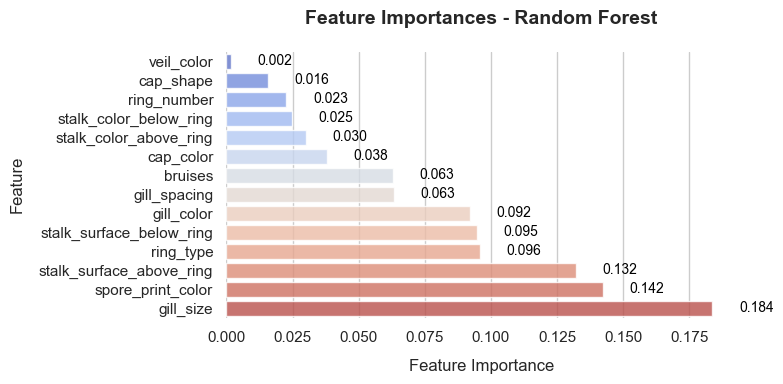

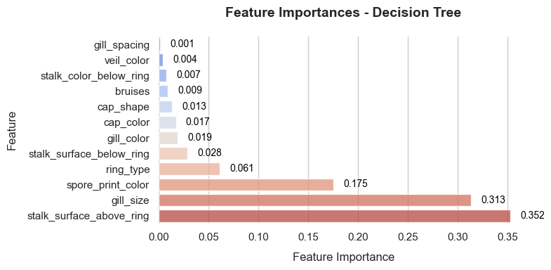

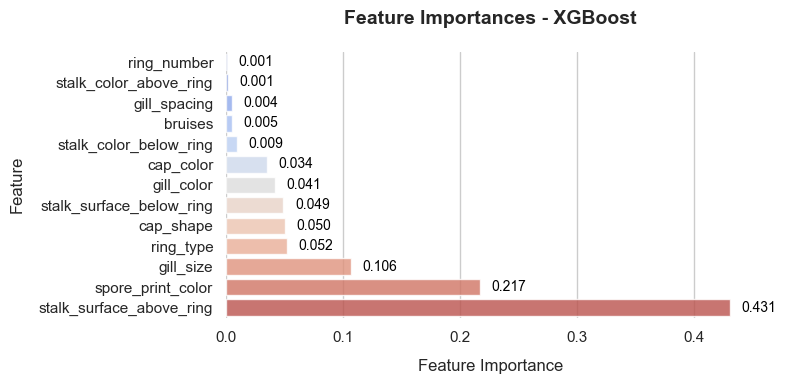

```python
# Set Seaborn style for better aesthetics
sns.set_theme(style="whitegrid")

# Loop through each column and plot a horizontal bar chart
for column in aggregated_df.columns:
    # Filter out features with zero importance
    non_zero_features = aggregated_df[column][aggregated_df[column] != 0]

    # Check if there are any non-zero features to plot
    if not non_zero_features.empty:
        # Create the plot
        plt.figure(figsize=(8, 4))

        # Use Seaborn's barplot with `hue` and `legend=False`
        sns.barplot(
            x=non_zero_features.sort_values(),
            y=non_zero_features.sort_values().index,
            hue=non_zero_features.sort_values().index,  # Assign y to hue
            palette="coolwarm",
            alpha=0.8,
            legend=False
        )

        # Add labels and title
        plt.xlabel('Feature Importance', fontsize=12, labelpad=10)
        plt.ylabel('Feature', fontsize=12, labelpad=10)
        plt.title(f'Feature Importances - {column}', fontsize=14, pad=20, weight='bold')

        # Add data labels (importance values) to the bars
        for i, v in enumerate(non_zero_features.sort_values()):
            plt.text(v + 0.01, i, f'{v:.3f}', color='black', va='center', fontsize=10)

        # Remove spines (borders) for a cleaner look
        sns.despine(left=True, bottom=True)

        # Adjust layout for better spacing
        plt.tight_layout()

        # Show the plot
        plt.show()
    else:
        print(f"No non-zero feature importances found for {column}.")
```

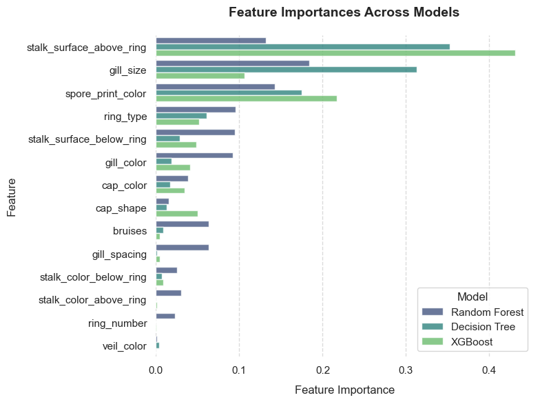

```python
# Step 1: Identify the union of non-zero features
non_zero_features = aggregated_df.index[aggregated_df.max(axis=1) > 0]

# Step 2: Create a subset DataFrame with only non-zero features
subset_df = aggregated_df.loc[non_zero_features]

# Step 3: Melt the DataFrame for Seaborn
melted_df = subset_df.reset_index().melt(id_vars='index', var_name='Model', value_name='Importance')

# Step 4: Plot side-by-side bars
plt.figure(figsize=(8, 6))
sns.barplot(
    x='Importance',
    y='index',
    hue='Model',
    data=melted_df,
    palette="viridis",
    alpha=0.8
)

# Add labels and title
plt.xlabel('Feature Importance', fontsize=12, labelpad=10)
plt.ylabel('Feature', fontsize=12, labelpad=10)
plt.title('Feature Importances Across Models', fontsize=14, pad=20, weight='bold')

# Add gridlines for better readability
plt.grid(axis='x', linestyle='--', alpha=0.7)

# Remove spines (borders) for a cleaner look
sns.despine(left=True, bottom=True)

# Adjust layout for better spacing
plt.tight_layout()

# Show the plot
plt.show()
```

So, those 3 models do not give the same importance to all features.

Below, we try to perform a grid search to try to find a better XGBoost model.

```python
from sklearn.model_selection import GridSearchCV
from sklearn.metrics import make_scorer, precision_score

# Define the model
model = xgb.XGBClassifier(random_state=42, eval_metric='logloss')

# Define the parameter grid to search
param_grid = {
    'max_depth': [3, 5, 7],  # Maximum depth of a tree
    'learning_rate': [0.01, 0.1, 0.2],  # Step size shrinkage
    'n_estimators': [50, 100, 200],  # Number of boosting rounds
    'subsample': [0.8, 1.0],  # Subsample ratio of the training instances
    'colsample_bytree': [0.8, 1.0],  # Subsample ratio of columns when constructing each tree
    'scale_pos_weight': [1, 12]  # Control the balance of positive and negative weights
}

# Use precision as the scoring metric
scorer = make_scorer(precision_score)

# Perform grid search
grid_search = GridSearchCV(
    estimator=model,
    param_grid=param_grid,
    scoring=scorer,  # Optimize for precision
    cv=5,  # 5-fold cross-validation
    n_jobs=-1  # Use all available CPU cores
)

# Use precision as the scoring metric
scorer = make_scorer(precision_score)

# Perform grid search
grid_search = GridSearchCV(model, param_grid, scoring=scorer, cv=5)
grid_search.fit(X_filtered_train, y_filtered_train)

# Get the best model
best_model = grid_search.best_estimator_
best_params = grid_search.best_params_
print(f"Best params: {best_params}")
```

```
Best params: {'colsample_bytree': 0.8, 'learning_rate': 0.1, 'max_depth': 7, 'n_estimators': 100, 'scale_pos_weight': 1, 'subsample': 0.8}
```

```python
from sklearn.metrics import (accuracy_score, recall_score, precision_score,
                             f1_score, roc_auc_score, confusion_matrix)

# Predict on test data
y_filtered_pred = best_model.predict(X_filtered_test)

# Evaluate the model
accuracy = accuracy_score(y_filtered_test, y_filtered_pred)
recall = recall_score(y_filtered_test, y_filtered_pred)
precision = precision_score(y_filtered_test, y_filtered_pred)
f1 = f1_score(y_filtered_test, y_filtered_pred)
roc_auc = roc_auc_score(y_filtered_test, y_filtered_pred)
conf_matrix = confusion_matrix(y_filtered_test, y_filtered_pred)

# Store performance metrics
best_performance_metrics = {
            'accuracy': accuracy,
            'recall': recall,
            'precision': precision,
            'f1': f1,
            'roc_auc': roc_auc,
            'confusion_matrix': conf_matrix
            }
```

```python
# Convert the dictionary to a DataFrame
df = pd.DataFrame(list(best_performance_metrics.items()), columns=['Metric', 'Value'])
df
```

|  | Metric | Value |
| --- | --- | --- |
| 0 | accuracy | 0.997948 |
| 1 | recall | 0.99914 |
| 2 | precision | 0.996569 |
| 3 | f1 | 0.997853 |
| 4 | roc_auc | 0.998 |
| 5 | confusion_matrix | [[1270, 4], [1, 1162]] |

I am not going to spend too much time trying the find the best parameters for these models, rather, I will try a Multilayer Perceptron approach (check the notebook `mushrooms_classification_mlp.ipynb`.)